# Risk Factor Analysis

## Outcome Variable

**Outcome Variable:** wasted

## Predictor Variables

**Intervention Variable:** vagbrth

**Adjustment Set:**

- arm
- sex
- W_mage
- meducyrs
- feducyrs
- hhwealth_quart
- W_mhtcm
- W_mwtkg
- W_mbmi
- single
- W_nrooms
- brthmon
- W_parity
- impfloor
- delta_W_mage
- delta_meducyrs
- delta_feducyrs
- delta_hhwealth_quart
- delta_W_mhtcm
- delta_W_mwtkg
- delta_W_mbmi
- delta_single
- delta_W_nrooms
- delta_brthmon
- delta_W_parity
- delta_impfloor

## Stratifying Variables

The analysis was stratified on these variable(s):

- agecat
- studyid
- country

## Data Summary

| agecat | studyid | country | vagbrth | wasted | n_cell | n |
| --- | --- | --- | --- | --- | --- | --- |
| Birth | ki1000108-CMC-V-BCS-2002 | INDIA | 0 | 0 | 8 | 86 |
| Birth | ki1000108-CMC-V-BCS-2002 | INDIA | 0 | 1 | 2 | 86 |
| Birth | ki1000108-CMC-V-BCS-2002 | INDIA | 1 | 0 | 67 | 86 |
| Birth | ki1000108-CMC-V-BCS-2002 | INDIA | 1 | 1 | 9 | 86 |
| Birth | ki1000108-IRC | INDIA | 0 | 0 | 45 | 343 |
| Birth | ki1000108-IRC | INDIA | 0 | 1 | 21 | 343 |
| Birth | ki1000108-IRC | INDIA | 1 | 0 | 206 | 343 |
| Birth | ki1000108-IRC | INDIA | 1 | 1 | 71 | 343 |
| Birth | ki1017093b-PROVIDE | BANGLADESH | 0 | 0 | 85 | 532 |
| Birth | ki1017093b-PROVIDE | BANGLADESH | 0 | 1 | 23 | 532 |
| Birth | ki1017093b-PROVIDE | BANGLADESH | 1 | 0 | 330 | 532 |
| Birth | ki1017093b-PROVIDE | BANGLADESH | 1 | 1 | 94 | 532 |
| Birth | ki1017093c-NIH-Crypto | BANGLADESH | 0 | 0 | 150 | 465 |
| Birth | ki1017093c-NIH-Crypto | BANGLADESH | 0 | 1 | 34 | 465 |
| Birth | ki1017093c-NIH-Crypto | BANGLADESH | 1 | 0 | 220 | 465 |
| Birth | ki1017093c-NIH-Crypto | BANGLADESH | 1 | 1 | 61 | 465 |
| Birth | ki1119695-PROBIT | BELARUS | 0 | 0 | 1304 | 13830 |
| Birth | ki1119695-PROBIT | BELARUS | 0 | 1 | 289 | 13830 |
| Birth | ki1119695-PROBIT | BELARUS | 1 | 0 | 9639 | 13830 |
| Birth | ki1119695-PROBIT | BELARUS | 1 | 1 | 2598 | 13830 |
| Birth | ki1126311-ZVITAMBO | ZIMBABWE | 0 | 0 | 906 | 12814 |
| Birth | ki1126311-ZVITAMBO | ZIMBABWE | 0 | 1 | 194 | 12814 |
| Birth | ki1126311-ZVITAMBO | ZIMBABWE | 1 | 0 | 9861 | 12814 |
| Birth | ki1126311-ZVITAMBO | ZIMBABWE | 1 | 1 | 1853 | 12814 |
| Birth | kiGH5241-JiVitA-3 | BANGLADESH | 0 | 0 | 398 | 17985 |
| Birth | kiGH5241-JiVitA-3 | BANGLADESH | 0 | 1 | 102 | 17985 |
| Birth | kiGH5241-JiVitA-3 | BANGLADESH | 1 | 0 | 15618 | 17985 |
| Birth | kiGH5241-JiVitA-3 | BANGLADESH | 1 | 1 | 1867 | 17985 |
| Birth | kiGH5241-JiVitA-4 | BANGLADESH | 0 | 0 | 57 | 2395 |
| Birth | kiGH5241-JiVitA-4 | BANGLADESH | 0 | 1 | 14 | 2395 |

[output cut: 74 more lines]

The following strata were considered:

- agecat: 24 months, studyid: ki1000108-CMC-V-BCS-2002, country: INDIA
- agecat: 24 months, studyid: ki1000108-IRC, country: INDIA
- agecat: 24 months, studyid: ki1017093b-PROVIDE, country: BANGLADESH
- agecat: 24 months, studyid: ki1017093c-NIH-Crypto, country: BANGLADESH
- agecat: 24 months, studyid: ki1066203-TanzaniaChild2, country: TANZANIA, UNITED REPUBLIC OF
- agecat: 24 months, studyid: ki1119695-PROBIT, country: BELARUS
- agecat: 24 months, studyid: ki1126311-ZVITAMBO, country: ZIMBABWE
- agecat: 24 months, studyid: kiGH5241-JiVitA-3, country: BANGLADESH
- agecat: 24 months, studyid: kiGH5241-JiVitA-4, country: BANGLADESH
- agecat: 6 months, studyid: ki1000108-CMC-V-BCS-2002, country: INDIA
- agecat: 6 months, studyid: ki1000108-IRC, country: INDIA
- agecat: 6 months, studyid: ki1017093b-PROVIDE, country: BANGLADESH
- agecat: 6 months, studyid: ki1017093c-NIH-Crypto, country: BANGLADESH
- agecat: 6 months, studyid: ki1066203-TanzaniaChild2, country: TANZANIA, UNITED REPUBLIC OF
- agecat: 6 months, studyid: ki1119695-PROBIT, country: BELARUS
- agecat: 6 months, studyid: ki1126311-ZVITAMBO, country: ZIMBABWE
- agecat: 6 months, studyid: kiGH5241-JiVitA-3, country: BANGLADESH
- agecat: 6 months, studyid: kiGH5241-JiVitA-4, country: BANGLADESH
- agecat: Birth, studyid: ki1000108-CMC-V-BCS-2002, country: INDIA
- agecat: Birth, studyid: ki1000108-IRC, country: INDIA
- agecat: Birth, studyid: ki1017093b-PROVIDE, country: BANGLADESH
- agecat: Birth, studyid: ki1017093c-NIH-Crypto, country: BANGLADESH
- agecat: Birth, studyid: ki1119695-PROBIT, country: BELARUS
- agecat: Birth, studyid: ki1126311-ZVITAMBO, country: ZIMBABWE
- agecat: Birth, studyid: kiGH5241-JiVitA-3, country: BANGLADESH
- agecat: Birth, studyid: kiGH5241-JiVitA-4, country: BANGLADESH

### Dropped Strata

Some strata were dropped due to rare outcomes:

- agecat: Birth, studyid: ki1000108-CMC-V-BCS-2002, country: INDIA
- agecat: 6 months, studyid: ki1000108-CMC-V-BCS-2002, country: INDIA
- agecat: 6 months, studyid: ki1017093c-NIH-Crypto, country: BANGLADESH
- agecat: 24 months, studyid: ki1000108-CMC-V-BCS-2002, country: INDIA
- agecat: 24 months, studyid: ki1066203-TanzaniaChild2, country: TANZANIA, UNITED REPUBLIC OF
- agecat: 24 months, studyid: ki1119695-PROBIT, country: BELARUS
- agecat: 24 months, studyid: ki1126311-ZVITAMBO, country: ZIMBABWE

## Methods Detail

We’re interested in the causal parameters $E[Y_a]$ for all values of $a \in \mathcal{A}$. These parameters represent the mean outcome if, possibly contrary to fact, we intervened to set all units to have $A=a$. Under the randomization and positivity assumptions, these are identified by the statistical parameters $\psi_a=E_W[E_{Y|A,W}(Y|A=a,W)]$. In addition, we’re interested in the mean of $Y$, $E[Y]$ under no intervention (the observed mean). We will estimate these parameters by using SuperLearner to fit the relevant likelihood factors – $E_{Y|A,W}(Y|A=a,W)$ and $p(A=a|W)$, and then updating our likelihood fit using a joint TMLE.

For unadjusted analyses ($W=\{\}$), initial likelihoods were estimated using Lrnr_glm to estimate the simple $E(Y|A)$ and Lrnr_mean to estimate $p(A)$. For adjusted analyses, a small library containing Lrnr_glmnet, Lrnr_xgboost, and Lrnr_mean was used.

Having estimated these parameters, we will then use the delta method to estimate relative risks and attributable risks relative to a prespecified baseline level of $A$.

# Results Detail

## Results Plots

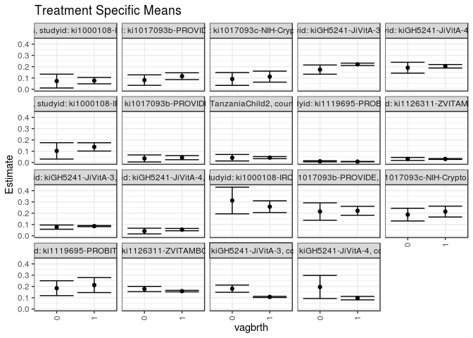

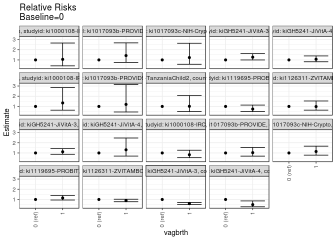

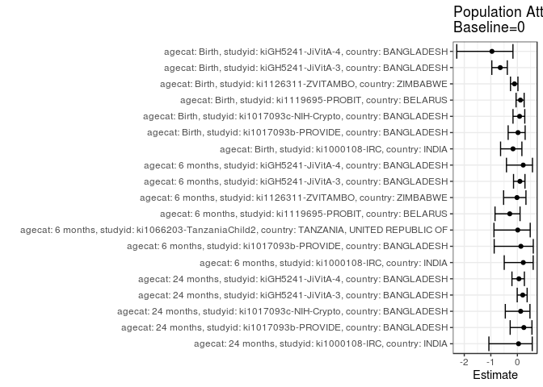

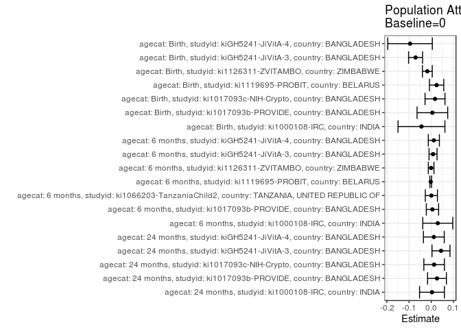

## Results Table

### Parameter: TSM

| agecat | studyid | country | intervention_level | baseline_level | estimate | ci_lower | ci_upper |
| --- | --- | --- | --- | --- | --- | --- | --- |
| Birth | ki1000108-IRC | INDIA | 0 | NA | 0.3123205 | 0.1940200 | 0.4306210 |
| Birth | ki1000108-IRC | INDIA | 1 | NA | 0.2577352 | 0.2059021 | 0.3095683 |
| Birth | ki1017093b-PROVIDE | BANGLADESH | 0 | NA | 0.2147727 | 0.1375651 | 0.2919802 |
| Birth | ki1017093b-PROVIDE | BANGLADESH | 1 | NA | 0.2211426 | 0.1816147 | 0.2606704 |
| Birth | ki1017093c-NIH-Crypto | BANGLADESH | 0 | NA | 0.1873032 | 0.1311260 | 0.2434803 |
| Birth | ki1017093c-NIH-Crypto | BANGLADESH | 1 | NA | 0.2142540 | 0.1660612 | 0.2624468 |
| Birth | ki1119695-PROBIT | BELARUS | 0 | NA | 0.1846079 | 0.1186268 | 0.2505889 |
| Birth | ki1119695-PROBIT | BELARUS | 1 | NA | 0.2120429 | 0.1455977 | 0.2784881 |
| Birth | ki1126311-ZVITAMBO | ZIMBABWE | 0 | NA | 0.1773615 | 0.1540846 | 0.2006383 |
| Birth | ki1126311-ZVITAMBO | ZIMBABWE | 1 | NA | 0.1585323 | 0.1519103 | 0.1651544 |
| Birth | kiGH5241-JiVitA-3 | BANGLADESH | 0 | NA | 0.1801420 | 0.1481496 | 0.2121343 |
| Birth | kiGH5241-JiVitA-3 | BANGLADESH | 1 | NA | 0.1072232 | 0.1019902 | 0.1124562 |
| Birth | kiGH5241-JiVitA-4 | BANGLADESH | 0 | NA | 0.1953294 | 0.0929233 | 0.2977354 |
| Birth | kiGH5241-JiVitA-4 | BANGLADESH | 1 | NA | 0.0967059 | 0.0813412 | 0.1120706 |
| 6 months | ki1000108-IRC | INDIA | 0 | NA | 0.1029412 | 0.0306257 | 0.1752567 |
| 6 months | ki1000108-IRC | INDIA | 1 | NA | 0.1382353 | 0.1015032 | 0.1749674 |
| 6 months | ki1017093b-PROVIDE | BANGLADESH | 0 | NA | 0.0359712 | 0.0049882 | 0.0669542 |
| 6 months | ki1017093b-PROVIDE | BANGLADESH | 1 | NA | 0.0431034 | 0.0246091 | 0.0615978 |
| 6 months | ki1066203-TanzaniaChild2 | TANZANIA, UNITED REPUBLIC OF | 0 | NA | 0.0423280 | 0.0136171 | 0.0710390 |
| 6 months | ki1066203-TanzaniaChild2 | TANZANIA, UNITED REPUBLIC OF | 1 | NA | 0.0429752 | 0.0336429 | 0.0523075 |
| 6 months | ki1119695-PROBIT | BELARUS | 0 | NA | 0.0106185 | 0.0058706 | 0.0153664 |
| 6 months | ki1119695-PROBIT | BELARUS | 1 | NA | 0.0079299 | 0.0063540 | 0.0095059 |
| 6 months | ki1126311-ZVITAMBO | ZIMBABWE | 0 | NA | 0.0315006 | 0.0182054 | 0.0447959 |
| 6 months | ki1126311-ZVITAMBO | ZIMBABWE | 1 | NA | 0.0311158 | 0.0272263 | 0.0350054 |
| 6 months | kiGH5241-JiVitA-3 | BANGLADESH | 0 | NA | 0.0766762 | 0.0579511 | 0.0954013 |
| 6 months | kiGH5241-JiVitA-3 | BANGLADESH | 1 | NA | 0.0854191 | 0.0805005 | 0.0903378 |
| 6 months | kiGH5241-JiVitA-4 | BANGLADESH | 0 | NA | 0.0417293 | 0.0165138 | 0.0669449 |
| 6 months | kiGH5241-JiVitA-4 | BANGLADESH | 1 | NA | 0.0545804 | 0.0442972 | 0.0648637 |
| 24 months | ki1000108-IRC | INDIA | 0 | NA | 0.0724638 | 0.0112173 | 0.1337102 |
| 24 months | ki1000108-IRC | INDIA | 1 | NA | 0.0764706 | 0.0481884 | 0.1047528 |
| 24 months | ki1017093b-PROVIDE | BANGLADESH | 0 | NA | 0.0810938 | 0.0347608 | 0.1274269 |
| 24 months | ki1017093b-PROVIDE | BANGLADESH | 1 | NA | 0.1156197 | 0.0855448 | 0.1456946 |
| 24 months | ki1017093c-NIH-Crypto | BANGLADESH | 0 | NA | 0.0909091 | 0.0341710 | 0.1476472 |
| 24 months | ki1017093c-NIH-Crypto | BANGLADESH | 1 | NA | 0.1118012 | 0.0630315 | 0.1605710 |
| 24 months | kiGH5241-JiVitA-3 | BANGLADESH | 0 | NA | 0.1741653 | 0.1333777 | 0.2149530 |
| 24 months | kiGH5241-JiVitA-3 | BANGLADESH | 1 | NA | 0.2210260 | 0.2106323 | 0.2314197 |
| 24 months | kiGH5241-JiVitA-4 | BANGLADESH | 0 | NA | 0.1905907 | 0.1423023 | 0.2388791 |
| 24 months | kiGH5241-JiVitA-4 | BANGLADESH | 1 | NA | 0.2034985 | 0.1880485 | 0.2189485 |

### Parameter: E(Y)

| agecat | studyid | country | intervention_level | baseline_level | estimate | ci_lower | ci_upper |
| --- | --- | --- | --- | --- | --- | --- | --- |
| Birth | ki1000108-IRC | INDIA | NA | NA | 0.2682216 | 0.2212677 | 0.3151755 |
| Birth | ki1017093b-PROVIDE | BANGLADESH | NA | NA | 0.2199248 | 0.1846953 | 0.2551543 |
| Birth | ki1017093c-NIH-Crypto | BANGLADESH | NA | NA | 0.2043011 | 0.1676152 | 0.2409869 |
| Birth | ki1119695-PROBIT | BELARUS | NA | NA | 0.2087491 | 0.1435025 | 0.2739957 |
| Birth | ki1126311-ZVITAMBO | ZIMBABWE | NA | NA | 0.1597472 | 0.1534034 | 0.1660909 |
| Birth | kiGH5241-JiVitA-3 | BANGLADESH | NA | NA | 0.1094801 | 0.1043667 | 0.1145935 |
| Birth | kiGH5241-JiVitA-4 | BANGLADESH | NA | NA | 0.0997912 | 0.0844161 | 0.1151664 |
| 6 months | ki1000108-IRC | INDIA | NA | NA | 0.1323529 | 0.0994307 | 0.1652752 |
| 6 months | ki1017093b-PROVIDE | BANGLADESH | NA | NA | 0.0414594 | 0.0255348 | 0.0573839 |
| 6 months | ki1066203-TanzaniaChild2 | TANZANIA, UNITED REPUBLIC OF | NA | NA | 0.0429142 | 0.0340389 | 0.0517895 |
| 6 months | ki1119695-PROBIT | BELARUS | NA | NA | 0.0082498 | 0.0066007 | 0.0098989 |
| 6 months | ki1126311-ZVITAMBO | ZIMBABWE | NA | NA | 0.0310537 | 0.0273521 | 0.0347553 |
| 6 months | kiGH5241-JiVitA-3 | BANGLADESH | NA | NA | 0.0847650 | 0.0799741 | 0.0895560 |
| 6 months | kiGH5241-JiVitA-4 | BANGLADESH | NA | NA | 0.0535010 | 0.0438560 | 0.0631459 |
| 24 months | ki1000108-IRC | INDIA | NA | NA | 0.0757946 | 0.0501131 | 0.1014762 |
| 24 months | ki1017093b-PROVIDE | BANGLADESH | NA | NA | 0.1070812 | 0.0818727 | 0.1322897 |
| 24 months | ki1017093c-NIH-Crypto | BANGLADESH | NA | NA | 0.1038462 | 0.0666939 | 0.1409984 |
| 24 months | kiGH5241-JiVitA-3 | BANGLADESH | NA | NA | 0.2182350 | 0.2083008 | 0.2281691 |
| 24 months | kiGH5241-JiVitA-4 | BANGLADESH | NA | NA | 0.2023453 | 0.1877652 | 0.2169254 |

### Parameter: RR

| agecat | studyid | country | intervention_level | baseline_level | estimate | ci_lower | ci_upper |
| --- | --- | --- | --- | --- | --- | --- | --- |
| Birth | ki1000108-IRC | INDIA | 0 | 0 | 1.0000000 | 1.0000000 | 1.0000000 |
| Birth | ki1000108-IRC | INDIA | 1 | 0 | 0.8252268 | 0.5370207 | 1.2681060 |
| Birth | ki1017093b-PROVIDE | BANGLADESH | 0 | 0 | 1.0000000 | 1.0000000 | 1.0000000 |
| Birth | ki1017093b-PROVIDE | BANGLADESH | 1 | 0 | 1.0296588 | 0.6892925 | 1.5380948 |
| Birth | ki1017093c-NIH-Crypto | BANGLADESH | 0 | 0 | 1.0000000 | 1.0000000 | 1.0000000 |
| Birth | ki1017093c-NIH-Crypto | BANGLADESH | 1 | 0 | 1.1438889 | 0.7859005 | 1.6649458 |
| Birth | ki1119695-PROBIT | BELARUS | 0 | 0 | 1.0000000 | 1.0000000 | 1.0000000 |
| Birth | ki1119695-PROBIT | BELARUS | 1 | 0 | 1.1486122 | 0.9484332 | 1.3910415 |
| Birth | ki1126311-ZVITAMBO | ZIMBABWE | 0 | 0 | 1.0000000 | 1.0000000 | 1.0000000 |
| Birth | ki1126311-ZVITAMBO | ZIMBABWE | 1 | 0 | 0.8938376 | 0.7788684 | 1.0257774 |
| Birth | kiGH5241-JiVitA-3 | BANGLADESH | 0 | 0 | 1.0000000 | 1.0000000 | 1.0000000 |
| Birth | kiGH5241-JiVitA-3 | BANGLADESH | 1 | 0 | 0.5952150 | 0.4942135 | 0.7168580 |
| Birth | kiGH5241-JiVitA-4 | BANGLADESH | 0 | 0 | 1.0000000 | 1.0000000 | 1.0000000 |
| Birth | kiGH5241-JiVitA-4 | BANGLADESH | 1 | 0 | 0.4950917 | 0.2851944 | 0.8594689 |
| 6 months | ki1000108-IRC | INDIA | 0 | 0 | 1.0000000 | 1.0000000 | 1.0000000 |
| 6 months | ki1000108-IRC | INDIA | 1 | 0 | 1.3428571 | 0.6336429 | 2.8458701 |
| 6 months | ki1017093b-PROVIDE | BANGLADESH | 0 | 0 | 1.0000000 | 1.0000000 | 1.0000000 |
| 6 months | ki1017093b-PROVIDE | BANGLADESH | 1 | 0 | 1.1982759 | 0.4577659 | 3.1366798 |
| 6 months | ki1066203-TanzaniaChild2 | TANZANIA, UNITED REPUBLIC OF | 0 | 0 | 1.0000000 | 1.0000000 | 1.0000000 |
| 6 months | ki1066203-TanzaniaChild2 | TANZANIA, UNITED REPUBLIC OF | 1 | 0 | 1.0152893 | 0.4980591 | 2.0696586 |
| 6 months | ki1119695-PROBIT | BELARUS | 0 | 0 | 1.0000000 | 1.0000000 | 1.0000000 |
| 6 months | ki1119695-PROBIT | BELARUS | 1 | 0 | 0.7468049 | 0.4919787 | 1.1336213 |
| 6 months | ki1126311-ZVITAMBO | ZIMBABWE | 0 | 0 | 1.0000000 | 1.0000000 | 1.0000000 |
| 6 months | ki1126311-ZVITAMBO | ZIMBABWE | 1 | 0 | 0.9877840 | 0.6360720 | 1.5339729 |
| 6 months | kiGH5241-JiVitA-3 | BANGLADESH | 0 | 0 | 1.0000000 | 1.0000000 | 1.0000000 |
| 6 months | kiGH5241-JiVitA-3 | BANGLADESH | 1 | 0 | 1.1140246 | 0.8705403 | 1.4256100 |
| 6 months | kiGH5241-JiVitA-4 | BANGLADESH | 0 | 0 | 1.0000000 | 1.0000000 | 1.0000000 |
| 6 months | kiGH5241-JiVitA-4 | BANGLADESH | 1 | 0 | 1.3079637 | 0.6938113 | 2.4657557 |
| 24 months | ki1000108-IRC | INDIA | 0 | 0 | 1.0000000 | 1.0000000 | 1.0000000 |
| 24 months | ki1000108-IRC | INDIA | 1 | 0 | 1.0552941 | 0.4194722 | 2.6548739 |
| 24 months | ki1017093b-PROVIDE | BANGLADESH | 0 | 0 | 1.0000000 | 1.0000000 | 1.0000000 |
| 24 months | ki1017093b-PROVIDE | BANGLADESH | 1 | 0 | 1.4257514 | 0.7610486 | 2.6710081 |
| 24 months | ki1017093c-NIH-Crypto | BANGLADESH | 0 | 0 | 1.0000000 | 1.0000000 | 1.0000000 |
| 24 months | ki1017093c-NIH-Crypto | BANGLADESH | 1 | 0 | 1.2298137 | 0.5743075 | 2.6335048 |
| 24 months | kiGH5241-JiVitA-3 | BANGLADESH | 0 | 0 | 1.0000000 | 1.0000000 | 1.0000000 |
| 24 months | kiGH5241-JiVitA-3 | BANGLADESH | 1 | 0 | 1.2690584 | 0.9979219 | 1.6138630 |
| 24 months | kiGH5241-JiVitA-4 | BANGLADESH | 0 | 0 | 1.0000000 | 1.0000000 | 1.0000000 |
| 24 months | kiGH5241-JiVitA-4 | BANGLADESH | 1 | 0 | 1.0677255 | 0.8193191 | 1.3914452 |

### Parameter: PAR

| agecat | studyid | country | intervention_level | baseline_level | estimate | ci_lower | ci_upper |
| --- | --- | --- | --- | --- | --- | --- | --- |
| Birth | ki1000108-IRC | INDIA | 0 | NA | -0.0440989 | -0.1499131 | 0.0617152 |
| Birth | ki1017093b-PROVIDE | BANGLADESH | 0 | NA | 0.0051522 | -0.0640158 | 0.0743201 |
| Birth | ki1017093c-NIH-Crypto | BANGLADESH | 0 | NA | 0.0169979 | -0.0279861 | 0.0619819 |
| Birth | ki1119695-PROBIT | BELARUS | 0 | NA | 0.0241412 | -0.0082864 | 0.0565688 |
| Birth | ki1126311-ZVITAMBO | ZIMBABWE | 0 | NA | -0.0176143 | -0.0398560 | 0.0046274 |
| Birth | kiGH5241-JiVitA-3 | BANGLADESH | 0 | NA | -0.0706619 | -0.1022498 | -0.0390740 |
| Birth | kiGH5241-JiVitA-4 | BANGLADESH | 0 | NA | -0.0955381 | -0.1961184 | 0.0050421 |
| 6 months | ki1000108-IRC | INDIA | 0 | NA | 0.0294118 | -0.0381917 | 0.0970152 |
| 6 months | ki1017093b-PROVIDE | BANGLADESH | 0 | NA | 0.0054881 | -0.0222783 | 0.0332546 |
| 6 months | ki1066203-TanzaniaChild2 | TANZANIA, UNITED REPUBLIC OF | 0 | NA | 0.0005861 | -0.0267563 | 0.0279285 |
| 6 months | ki1119695-PROBIT | BELARUS | 0 | NA | -0.0023687 | -0.0063053 | 0.0015679 |
| 6 months | ki1126311-ZVITAMBO | ZIMBABWE | 0 | NA | -0.0004470 | -0.0131679 | 0.0122740 |
| 6 months | kiGH5241-JiVitA-3 | BANGLADESH | 0 | NA | 0.0080889 | -0.0099873 | 0.0261650 |
| 6 months | kiGH5241-JiVitA-4 | BANGLADESH | 0 | NA | 0.0117717 | -0.0132378 | 0.0367811 |
| 24 months | ki1000108-IRC | INDIA | 0 | NA | 0.0033309 | -0.0527495 | 0.0594112 |
| 24 months | ki1017093b-PROVIDE | BANGLADESH | 0 | NA | 0.0259873 | -0.0164430 | 0.0684177 |
| 24 months | ki1017093c-NIH-Crypto | BANGLADESH | 0 | NA | 0.0129371 | -0.0334089 | 0.0592830 |
| 24 months | kiGH5241-JiVitA-3 | BANGLADESH | 0 | NA | 0.0440696 | 0.0034912 | 0.0846481 |
| 24 months | kiGH5241-JiVitA-4 | BANGLADESH | 0 | NA | 0.0117546 | -0.0351502 | 0.0586594 |

### Parameter: PAF

| agecat | studyid | country | intervention_level | baseline_level | estimate | ci_lower | ci_upper |
| --- | --- | --- | --- | --- | --- | --- | --- |
| Birth | ki1000108-IRC | INDIA | 0 | NA | -0.1644122 | -0.6330357 | 0.1697329 |
| Birth | ki1017093b-PROVIDE | BANGLADESH | 0 | NA | 0.0234269 | -0.3475908 | 0.2922962 |
| Birth | ki1017093c-NIH-Crypto | BANGLADESH | 0 | NA | 0.0832003 | -0.1650903 | 0.2785781 |
| Birth | ki1119695-PROBIT | BELARUS | 0 | NA | 0.1156470 | -0.0494106 | 0.2547433 |
| Birth | ki1126311-ZVITAMBO | ZIMBABWE | 0 | NA | -0.1102637 | -0.2585583 | 0.0205575 |
| Birth | kiGH5241-JiVitA-3 | BANGLADESH | 0 | NA | -0.6454309 | -0.9627197 | -0.3794343 |
| Birth | kiGH5241-JiVitA-4 | BANGLADESH | 0 | NA | -0.9573800 | -2.2830498 | -0.1670052 |
| 6 months | ki1000108-IRC | INDIA | 0 | NA | 0.2222222 | -0.4955071 | 0.5954962 |
| 6 months | ki1017093b-PROVIDE | BANGLADESH | 0 | NA | 0.1323741 | -0.8735818 | 0.5982163 |
| 6 months | ki1066203-TanzaniaChild2 | TANZANIA, UNITED REPUBLIC OF | 0 | NA | 0.0136582 | -0.8817567 | 0.4829989 |
| 6 months | ki1119695-PROBIT | BELARUS | 0 | NA | -0.2871235 | -0.8418230 | 0.1005179 |
| 6 months | ki1126311-ZVITAMBO | ZIMBABWE | 0 | NA | -0.0143930 | -0.5190772 | 0.3226195 |
| 6 months | kiGH5241-JiVitA-3 | BANGLADESH | 0 | NA | 0.0954269 | -0.1451797 | 0.2854812 |
| 6 months | kiGH5241-JiVitA-4 | BANGLADESH | 0 | NA | 0.2200271 | -0.4109116 | 0.5688194 |
| 24 months | ki1000108-IRC | INDIA | 0 | NA | 0.0439458 | -1.0726677 | 0.5590033 |
| 24 months | ki1017093b-PROVIDE | BANGLADESH | 0 | NA | 0.2426881 | -0.2718449 | 0.5490635 |
| 24 months | ki1017093c-NIH-Crypto | BANGLADESH | 0 | NA | 0.1245791 | -0.4545902 | 0.4731425 |
| 24 months | kiGH5241-JiVitA-3 | BANGLADESH | 0 | NA | 0.2019366 | -0.0065585 | 0.3672447 |
| 24 months | kiGH5241-JiVitA-4 | BANGLADESH | 0 | NA | 0.0580918 | -0.2044610 | 0.2634124 |